# Optimization for Scientific Models

Losses, gradients, and reliable parameter fitting

## Optimization for Scientific Models

Losses, gradients, and reliable parameter fitting

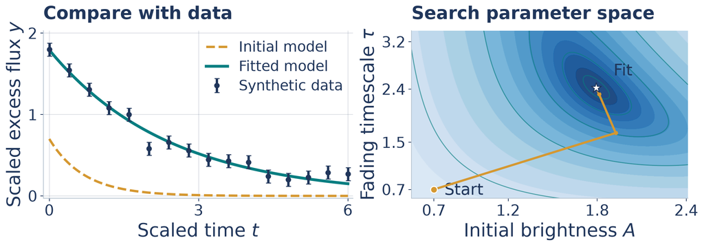

COMP 521 · Guide Lectures 3–4 · Anna Rosen

## What does the curve tell us?

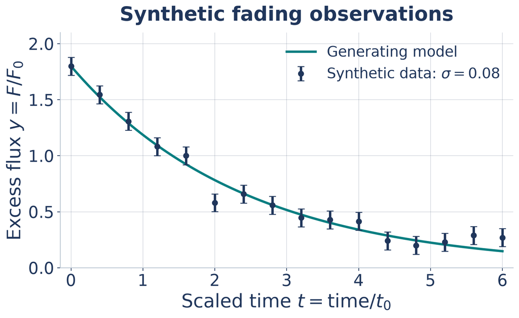

Notice

Which feature tells us the initial brightness? Which tells us how quickly it fades?

## Two parameters: height and fading time

$$y(t;A,\tau)=A e^{-t/\tau}.$$

### Amplitude $A$

Initial normalized excess flux: $y(0)=A$.

### Timescale $\tau$

Larger $\tau$ means slower fading.

$y=F/F_0$ and $t=T/t_0$ use fixed reference scales. Synthetic data; exponential relaxation is a teaching model.

## Separate prediction, comparison, and updating

### 1 · Predict

$$\mathbf y=\mathcal G(\boldsymbol\theta)$$

Parameters $\boldsymbol\theta$ are adjustable inputs. The forward model $\mathcal G$ predicts observations.

### 2 · Compare

$$\mathcal L(\boldsymbol\theta)$$

The loss is one number scoring mismatch with data.

### 3 · Update

$$\boldsymbol\theta_{k+1}$$

Propose new parameters.

The loss states the question. The optimizer chooses the next candidate.

## Physics and data have different residuals

A **residual** measures how far a prediction or equation is from its target.

### Inner physical solve

$$\mathbf R(\mathbf u,\boldsymbol\theta)=\mathbf0$$

**State variables $\mathbf u$** are computed, such as a stellar temperature profile.

### Outer data fit

$$\mathbf r=\mathcal G(\boldsymbol\theta)-\mathbf d$$

**Decision variables $\boldsymbol\theta$** are adjusted. Observations $\mathbf d$ stay fixed.

Our relaxation model has an analytic solution. A Jaxstro prediction may instead require a numerical physics solve. Measurement residuals can remain because the data contain noise.

## First, read the sign of a residual

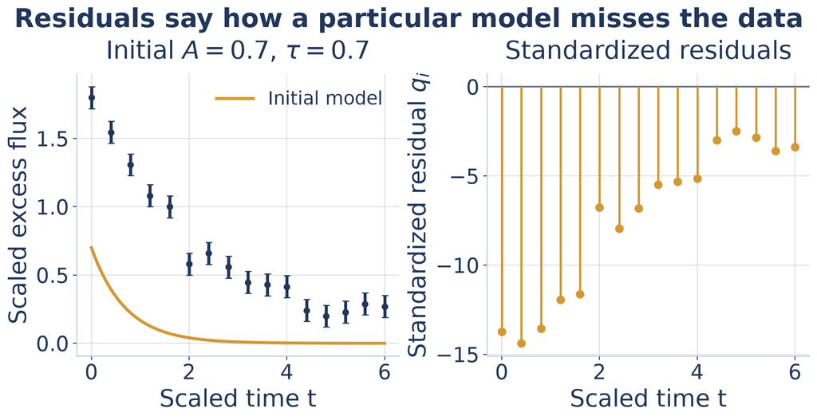

$$r_i=\text{prediction}_i-\text{observation}_i.$$

The plot shows $q_i=r_i/\sigma_i$. Because $\sigma_i>0$, a positive value means the model is too high.

## The same miss can matter more

Both measurements miss by $r=0.2$.

### Precise measurement

$$\sigma=0.1,\qquad q=r/\sigma=2.$$

### Noisier measurement

$$\sigma=0.4,\qquad q=r/\sigma=0.5.$$

Predict

Which mismatch should count more in the fit?

Explain

The first: its discrepancy is larger in measurement-uncertainty units.

$\sigma$ is measurement standard deviation. A standardized residual is $q_i=r_i/\sigma_i$.

## Gaussian errors lead to weighted least squares

**Measurement assumption:** independent errors with known, fixed standard deviations.

$$d_i=y_i(\boldsymbol\theta)+\epsilon_i,
\qquad \epsilon_i\sim\mathcal N(0,\sigma_i^2).$$

$\mathcal N(0,\sigma_i^2)$ means Gaussian errors centered on zero, with standard deviation $\sigma_i$.

$$\mathcal L=\frac12\sum_i q_i^2=\frac12\chi^2.$$

A residual twice as large in uncertainty units contributes four times as much.

$\chi^2$ is called chi-square: the sum of squared standardized residuals.

## Hold the data fixed; vary the parameters

**Likelihood:** the probability mass or density for the observed data, evaluated at different parameter choices.

$$p(\mathbf d\mid\boldsymbol\theta)$$

For the stated Gaussian model,

$$\mathcal L=-\log p(\mathbf d\mid\boldsymbol\theta)+\text{constant}.$$

Maximizing likelihood and minimizing negative log-likelihood choose the same candidate.

## Correlated errors change the comparison

**Whitening** changes residual coordinates so the assumed measurement errors have variance 1 in each coordinate and zero correlation between coordinates.

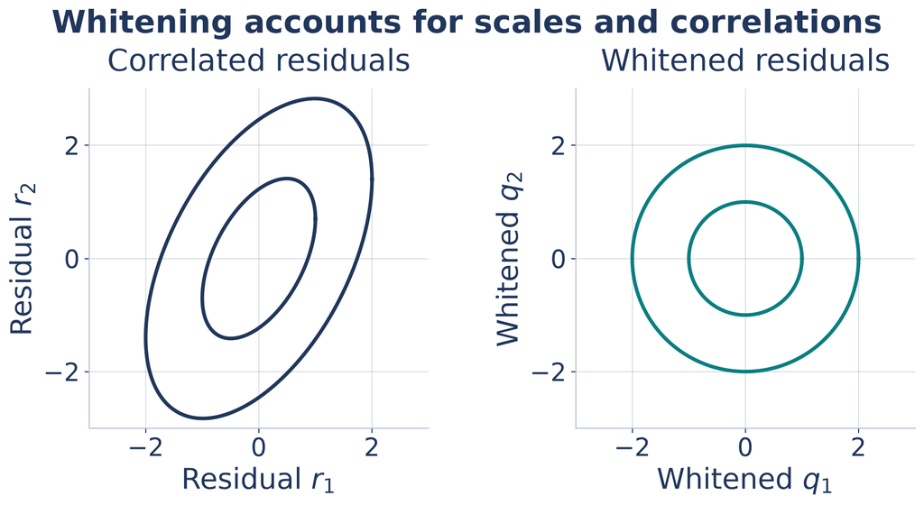

Here $\mathbf r$ denotes raw residuals (predictions minus observations), and $\mathbf q$ denotes whitened residuals. The covariance matrix $\Sigma$ stores variances on the diagonal and shared error variation off the diagonal.

## Positive definite means positive in every direction

For a symmetric matrix $M$,

$$\mathbf v^{\mathsf T}M\mathbf v>0\qquad\text{for every }\mathbf v\ne\mathbf0.$$

### Covariance

Every nonzero combination of errors has positive variance.

### Loss curvature

A positive-definite curvature matrix makes a local quadratic curve upward in every direction.

**Symmetric:** $M=M^{\mathsf T}$. The transpose $\mathsf T$ swaps rows and columns.

Example: $M=\begin{pmatrix}1&0\\0&4\end{pmatrix}$ gives $\mathbf v^{\mathsf T}M\mathbf v=v_1^2+4v_2^2>0$ for $\mathbf v\ne\mathbf0$.

## Cholesky factors the covariance

**Cholesky factorization** writes a symmetric positive-definite covariance as

$$\Sigma=C C^{\mathsf T}.$$

For two measurements,

$$C=\begin{pmatrix}c_{11}&0\\c_{21}&c_{22}\end{pmatrix},
\qquad c_{11},c_{22}>0.$$

**Lower triangular:** all entries above the diagonal are zero. A system with this structure can be solved one row at a time, starting at the top.

## Use the factor to standardize correlated errors

**Given:** known measurement-error covariance $\Sigma$ and its lower-triangular Cholesky factor $C$, with $\Sigma=CC^{\mathsf T}$.

$$C\mathbf q=\mathbf r.$$

### $\mathbf r$ · Raw residual vector

Model predictions minus observations.

### $\mathbf q$ · Whitened residual vector

The unknown vector we solve for.

For Gaussian errors with fixed $\Sigma$, the fit loss is ordinary squares in these coordinates.

$$\mathcal L=\tfrac12\lVert\mathbf q\rVert_2^2
=\tfrac12\sum_iq_i^2.$$

For fixed $\Sigma$, reuse $C$. Recompute $\mathbf r$ from each new model prediction, then solve for $\mathbf q$ again instead of constructing an inverse.

## A photon count needs a count model

Independent counts $n_i\sim\operatorname{Poisson}(\mu_i)$ have expected counts $\mu_i>0$.

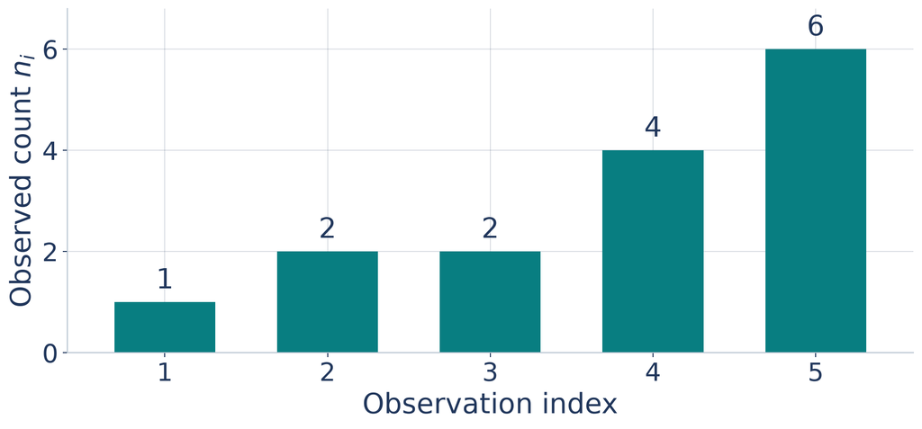

$$\mathcal L=\sum_i\left(\mu_i-n_i\log\mu_i\right)+\text{constant}.$$

**Poisson:** a distribution for integer event counts, with mean and variance both equal to $\mu_i$.

## Changing the weights changes the answer

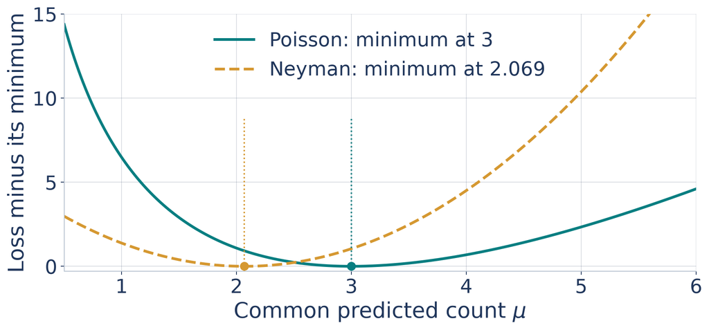

**Neyman weighting** gives larger weights to smaller observed counts, including downward fluctuations. It is undefined at $n_i=0$, which is valid Poisson data.

## Build one loss we can solve by hand

We have chosen how to compare. Now use one parameter to learn how to update.

### Model

$$y=1+2\theta$$

### Observation

$$d=3$$

### Uncertainty

$$\sigma=0.5$$

$$\mathcal L=\frac12\left(\frac{1+2\theta-3}{0.5}\right)^2.$$

Explain

This simplifies to $\boxed{\mathcal L=8(\theta-1)^2}$, with a minimum at $\theta=1$.

## A location and a value answer different questions

$$\mathcal L(\theta)=8(\theta-1)^2.$$

### Minimizing location

$$\theta^*=1$$

The **argmin** gives the location or locations.

### Minimum value

$$\mathcal L(\theta^*)=0$$

The **minimum** gives the best score.

The objective is the scalar score; the feasible set contains the allowed parameter values.

## The derivative gives the local direction

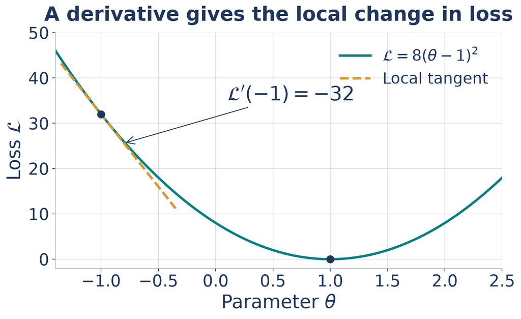

$$\mathcal L'(\theta)=16(\theta-1).$$

A derivative is a local rate of change. At $\theta=-1$, the slope is -32.

## Several parameters give several slopes

A **partial derivative** varies one parameter while holding the others fixed.

For two parameters,

$$\mathbf g=\nabla\mathcal L
=\begin{pmatrix}\partial\mathcal L/\partial\theta_1\\[4pt]\partial\mathcal L/\partial\theta_2\end{pmatrix}.$$

The gradient has one component per parameter, not per observation.

## Ask whether the local loss should decrease

A small proposed step $\mathbf s$ predicts

$$\Delta\mathcal L\approx\mathbf g^{\mathsf T}\mathbf s.$$

$$\mathbf g^{\mathsf T}\mathbf s<0$$

This is a **descent direction**.

The dot product sums $g_js_j$ over parameters. Steepest descent depends on the coordinate scales and distance measure.

## The Jacobian has a row for each residual

For the fading fit, choose $\boldsymbol\theta=(a,b)=(\log A,\log\tau)$.

These are **log coordinates**: $A=e^a$ and $\tau=e^b$ stay positive for any finite $a,b$.

$$J_{ij}=\frac{\partial q_i}{\partial\theta_j}.$$

### Rows: measurements

One row per standardized residual.

### Columns: parameters

One sensitivity pattern per parameter.

Predict

Sixteen observations, two parameters: what shape is $J$?

Explain

$J$ has 16 rows and 2 columns.

## Add the residual contributions to each slope

For $\mathcal L=\tfrac12\sum_iq_i^2$, the chain rule gives

$$\boxed{\mathbf g=J^{\mathsf T}\mathbf q}.$$

$$\underbrace{J^{\mathsf T}}_{2\times16}
\qquad\underbrace{\mathbf q}_{16\times1}
=\underbrace{\mathbf g}_{2\times1}.$$

Each slope combines the current mismatch with its sensitivity. The transpose $\mathsf T$ swaps rows and columns.

## Gradient descent is an update rule

$$\boldsymbol\theta_{k+1}=\boldsymbol\theta_k-\eta\mathbf g_k.$$

### Direction

$-\mathbf g_k$: move against the current slopes.

### Step scale

$\eta>0$ scales the gradient. The step length is $\eta\lVert\mathbf g_k\rVert_2$.

$k$ counts updates. Recompute the gradient after moving.

## Work the first update

Start at $\theta_0=-1$ with $\eta=1/32$.

Calibration loss

Step

**Slope:** $g_0=16(-1-1)=-32$.

Step

**Update:** $\theta_1=-1-(1/32)(-32)=0$.

Step

**Check:** the actual loss falls from 32 to 8.

The next update gives $\theta_2=0.5$ and loss 2.

## Predict the effect of the step size

For the calibration loss, $e_k=\theta_k-1$ and $e_{k+1}=(1-16\eta)e_k$.

Predict

Try $\eta=0.03,\ 0.09,\ 0.125,\ 0.14$. When does the error alternate? When does its magnitude shrink?

Explain

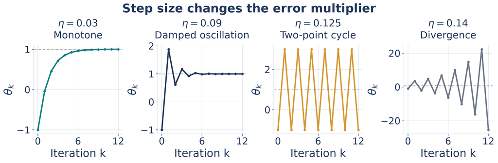

The first two converge. At $\eta=0.125$ the parameter alternates with constant loss.

## Stability comes from the error multiplier

Define the parameter error $e_k=\theta_k-1$.

$$e_{k+1}=(1-16\eta)e_k.$$

The error shrinks when

$$|1-16\eta|<1\quad\Longrightarrow\quad0<\eta<1/8.$$

Explain

Why does $\eta=1/16$ reach the minimum in one update?

Explain

Its error multiplier is zero. This result is specific to this quadratic.

## Curvature describes how slopes change

The **Hessian** collects second derivatives of one scalar loss:

$$H_{jk}=\frac{\partial^2\mathcal L}{\partial\theta_j\,\partial\theta_k}.$$

- $p$ parameters give a $p\times p$ Hessian.
- For the calibration, $\mathcal L''(\theta)=16$ everywhere.

The gradient tells us which way. Curvature tells us how quickly the slopes change.

## One direction can be much steeper

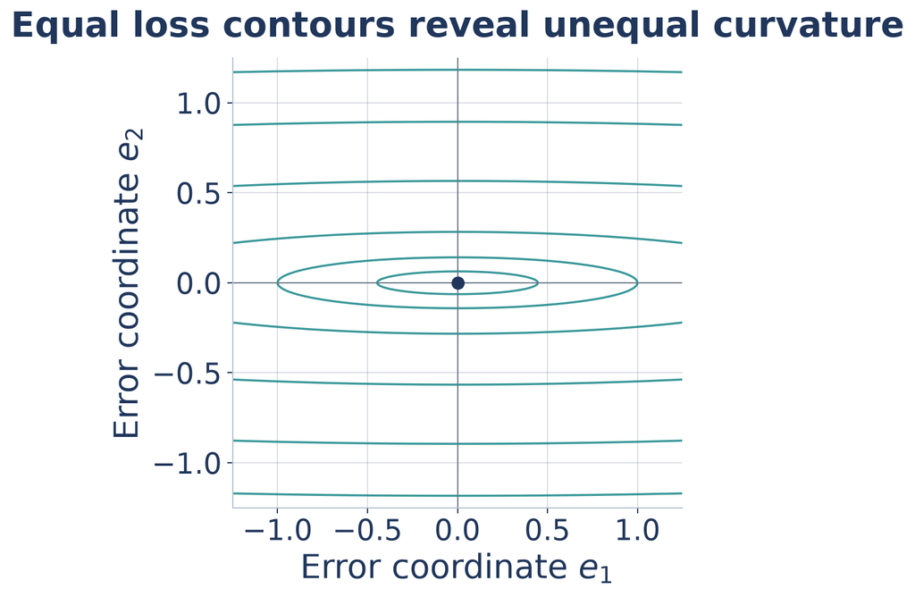

$$\mathcal L=\tfrac12(e_1^2+50e_2^2),\qquad H=\operatorname{diag}(1,50).$$

Parameter errors $e_1,e_2$ measure displacement from the minimum. Here $\operatorname{diag}(1,50)$ means diagonal entries $1,50$ and zeros elsewhere.

## Read curvature one direction at a time

$$H\mathbf v=\lambda\mathbf v.$$

An **eigenvector** $\mathbf v\ne\mathbf0$ keeps the same line under multiplication by $H$. Its **eigenvalue** $\lambda$ is the scale factor.

### Shallow direction

$\mathbf v=(1,0)^{\mathsf T}$ has $\lambda=1$.

### Steep direction

$\mathbf v=(0,1)^{\mathsf T}$ has $\lambda=50$.

For a symmetric Hessian and a **unit eigenvector** (length one), $\lambda$ is the curvature along that direction. Positive definite means all eigenvalues are positive.

## One step size must serve both directions

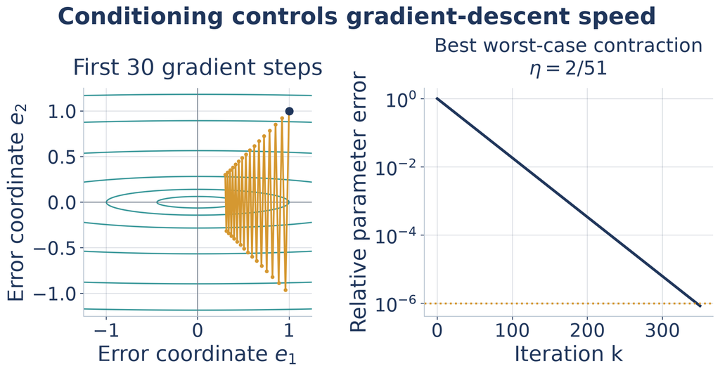

$$e_{j,k+1}=(1-\eta\lambda_j)e_{j,k},
\qquad \kappa=\frac{\lambda_{\max}}{\lambda_{\min}}=50.$$

The steep direction forces $\eta<0.04$. In the shallow direction ($\lambda=1$), $1-\eta$ stays close to one.

## Rescaling can turn an ellipse into a circle

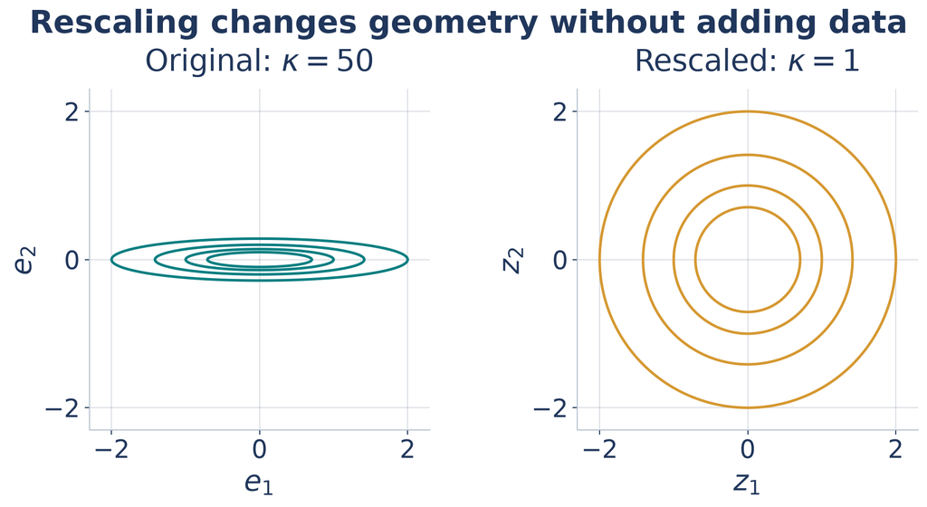

$$z_1=e_1,\qquad z_2=\sqrt{50}\,e_2.$$

**Preconditioning** changes coordinates or step geometry to make directional responses more balanced. **Nondimensionalization** expresses variables relative to fixed physical reference scales. Neither adds observations.

## Keep some of the previous motion

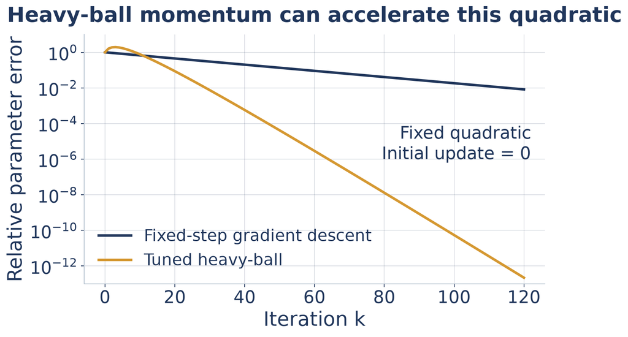

$$\mathbf v_{k+1}=\beta\mathbf v_k-\eta\mathbf g_k,$$

$$\boldsymbol\theta_{k+1}=\boldsymbol\theta_k+\mathbf v_{k+1}.$$

**Heavy-ball momentum:** $\mathbf v$ is the update; $\beta$ retains part of the previous update.

The plotted tuning is specific to this quadratic. Momentum can overshoot.

## Use a local quadratic model of the loss

At the current parameters, approximate the loss after a displacement $\mathbf s$ by

$$m(\mathbf s)=\mathcal L+\mathbf g^{\mathsf T}\mathbf s
+\tfrac12\mathbf s^{\mathsf T}H\mathbf s.$$

### Current value

$\mathcal L$

### Local slope

$\mathbf g^{\mathsf T}\mathbf s$

### Curvature

$\tfrac12\mathbf s^{\mathsf T}H\mathbf s$

## Solve for the Newton step

$$H\mathbf s=-\mathbf g.$$

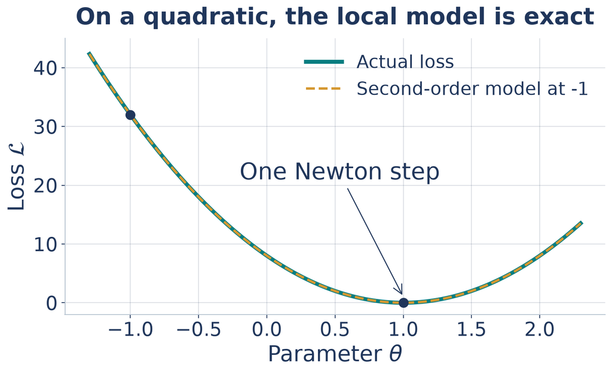

One exact update solves an unconstrained positive-definite quadratic. Solve the linear system; do not explicitly invert $H$.

## Zero slope does not identify a minimum

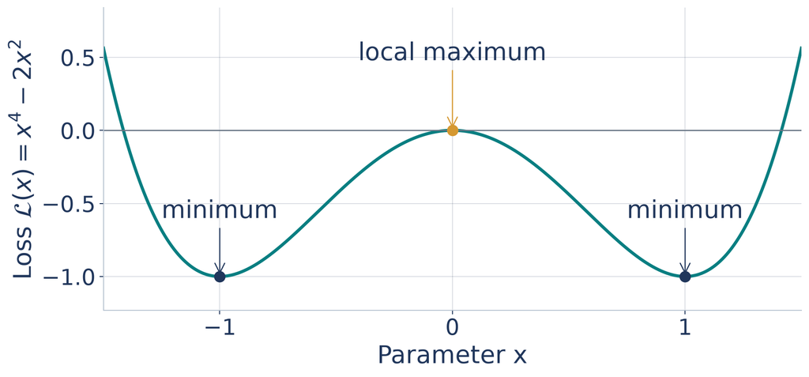

A stationary point has zero gradient. It can be a minimum, maximum, or saddle.

A **saddle** rises along some directions and falls along others. This one-dimensional plot shows only minima and a maximum.

## Negative curvature can send Newton uphill

For $\mathcal L(x)=x^4-2x^2$ at $x=0.25$, both the slope and curvature are negative.

Predict

Which way does $s=-g/H$ point? Is that a descent direction?

Explain

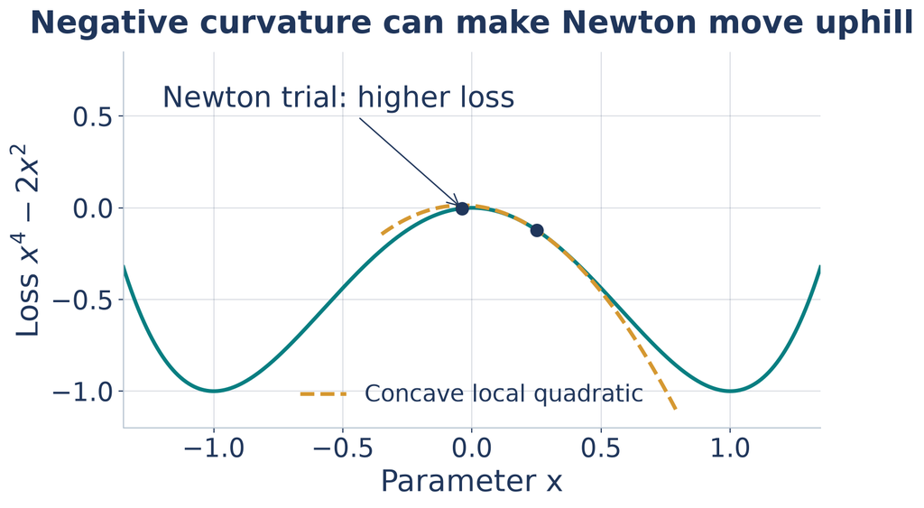

$$x:0.25\longrightarrow-0.0385,
\qquad \mathcal L:-0.1211\longrightarrow-0.0030.$$

## Limit how far you trust a local prediction

### Line search

Choose a descent direction. Shorten the step until the actual loss decreases enough.

### Trust region

Limit the step to a neighborhood where the local model is useful. Compare predicted and actual reduction.

Evaluate the actual objective before accepting a proposal.

## Linearize the residuals

Our loss is a sum of squared residuals. **Linearize:** approximate their changes using first derivatives.

$$\mathbf q(\boldsymbol\theta+\mathbf s)\approx\mathbf q+J\mathbf s.$$

### Current mismatch

$\mathbf q$

### Predicted change

$J\mathbf s$

Square the predicted residuals to get the local loss model $m(\mathbf s)=\tfrac12\lVert\mathbf q+J\mathbf s\rVert_2^2$.

## The Jacobian gives approximate loss curvature

$$\mathbf g=J^{\mathsf T}\mathbf q,
\qquad H_{\mathrm{GN}}=J^{\mathsf T}J.$$

$$\mathbf v^{\mathsf T}H_{\mathrm{GN}}\mathbf v=\lVert J\mathbf v\rVert_2^2\ge0.$$

**Positive semidefinite:** curvature is never negative, but flat directions can remain.

The approximation omits the curvature of individual residual functions. Evaluate the actual loss before accepting a nonlinear trial.

## Can the sensitivity columns distinguish changes?

Recall: one column of $J$ describes how all residuals respond to one parameter.

$$J\mathbf v=\mathbf0.$$

If a nonzero parameter change $\mathbf v$ satisfies this equation, it produces no change in the linearized residuals.

**Full column rank:** the columns are linearly independent. No nonzero combination of parameter changes cancels across every residual.

Then $J^{\mathsf T}J$ is positive definite. A nonzero gradient gives a Gauss–Newton descent direction, still subject to a trial-loss test.

## Solve the linearized least-squares problem

$$\mathbf s_{\mathrm{GN}}\in\underset{\mathbf s}{\operatorname{argmin}}
\frac12\lVert\mathbf q+J\mathbf s\rVert_2^2.$$

Use a least-squares solver

```python
step = np.linalg.lstsq(J, -q, rcond=None)[0]
```

Solve $J\mathbf s\approx-\mathbf q$ directly. Forming $J^{\mathsf T}J$ can amplify numerical sensitivity.

**Normal equations:** $J^{\mathsf T}J\mathbf s=-J^{\mathsf T}\mathbf q$. They express the same least-squares stationarity condition; the code avoids forming that product.

## Damping makes the proposal more conservative

$$\bigl(J^{\mathsf T}J+\nu I\bigr)\mathbf s=-\mathbf g.$$

### Large $\nu$

A short step toward the negative gradient.

### Small $\nu$

Approach Gauss–Newton when that step is well defined.

Levenberg–Marquardt uses positive damping $\nu$. The **identity matrix** leaves vectors unchanged: $I\mathbf v=\mathbf v$. Adding $\nu I$ adds positive curvature in every direction.

## Compare proposals from the same point

Predict

For $\nu=1,\ 100,\ 1000$, which proposal should move least? What measurement decides whether a trial is accepted?

Explain

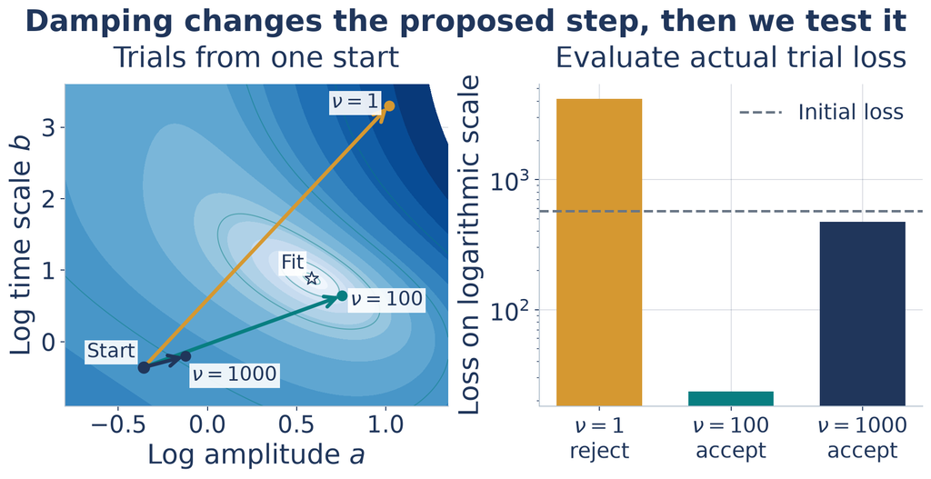

## A rejected trial keeps the current parameters

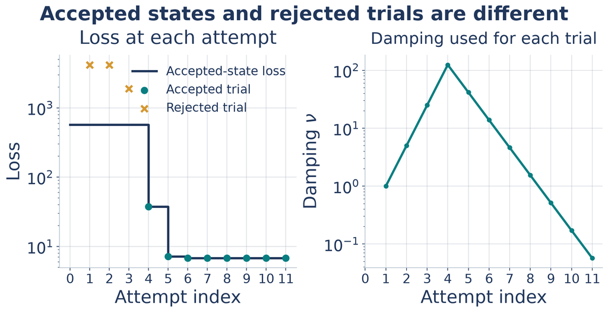

This run: 11 trials, 8 accepted, 3 rejected. Rejected trials still cost evaluations.

## Does the fitted curve explain the data?

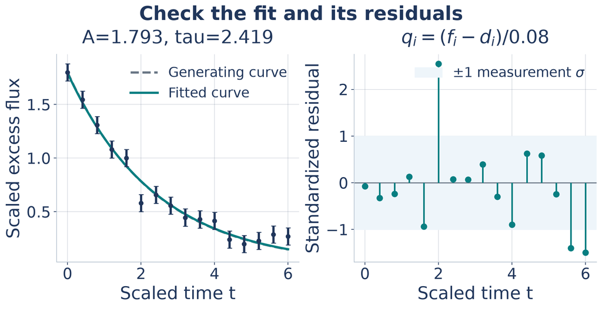

Inspect

At $t=2$, is the prediction high or low, and by how many measurement standard deviations? What pattern would make you question the model?

## Missing information leaves a flat direction

**Identifiability:** can different parameter choices be distinguished by their predictions?

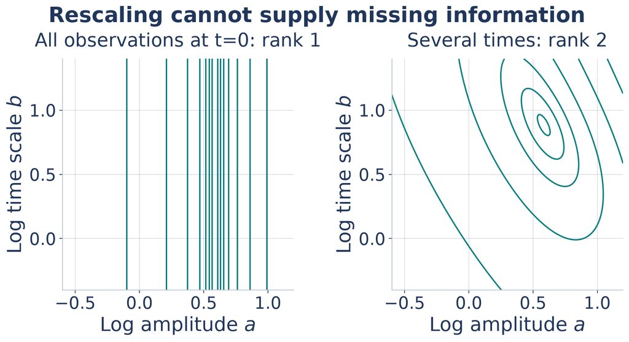

Choose the next measurement

You already measured $A$. Which gives new information about $\tau$: 100 more observations at $t=0$, or one at $t>0$?

## A penalty changes the question being fitted

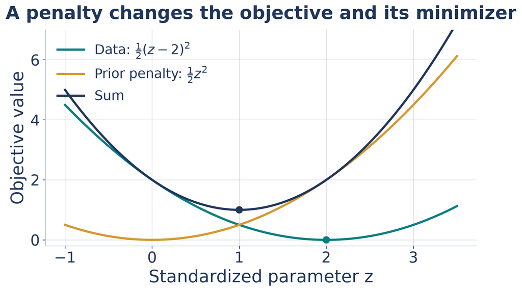

Regularization adds a stated preference. It can move the fitted answer.

## A Gaussian prior gives a quadratic penalty

In the chosen coordinates, a prior $\boldsymbol\theta\sim\mathcal N(\boldsymbol\theta_0,I/\lambda)$ adds a penalty to the negative log-likelihood, up to a constant.

$$\frac{\lambda}{2}\lVert\boldsymbol\theta-\boldsymbol\theta_0\rVert_2^2.$$

**MAP:** maximum a posteriori, the location maximizing posterior density.

**Prior:** parameter density before conditioning on data. **Posterior:** after conditioning.

$\boldsymbol\theta_0$ is the prior center and $\lambda>0$ sets its strength. LM damping penalizes the trial step $\mathbf s$ in the local model.

## Log coordinates enforce strict positivity

$$A=e^a,\qquad\tau=e^b.$$

- Any finite $a,b$ give $A,\tau>0$.
- The optimizer can vary $a,b$ without crossing a zero boundary.

Reparameterization changes the coordinates used to search.

The predictions and likelihood agree at corresponding values. State which coordinates you use for any prior.

## A valid zero needs a boundary-aware method

A separate background parameter may satisfy $B\ge0$, including $B=0$.

### Exponentiation

$$B=e^z>0$$

Approaches zero but never reaches it at finite $z$.

### Projection for this bound

$$B\leftarrow\max(0,B)$$

Projection can represent $B=0$ exactly.

Near a boundary, a small transformed gradient can be misleading.

## Match the optimizer to the problem

### Residual vector

Gauss–Newton or LM, with safeguards.

### General smooth loss

Quasi-Newton methods estimate curvature from changes in gradients.

### Noisy sampled gradients

Stochastic methods use gradients estimated from random data subsets. Momentum can help steady the updates.

BFGS is a quasi-Newton method. Adam adapts updates using running averages of gradients and squared gradients. Neither supplies missing data information.

## What would you check before trusting the fit?

Exit check

The gradient is small. Give one check each for the solver, the physical model, and what the data can tell you.

Explain

### Solver

Read the stop reason. Check the derivatives.

### Physical model

Inspect residuals for patterns.

### Inference

Check whether the data constrain the parameters.